# OXT in Interoception - Part II

## 2.2) OXTR rs53576

There is no significant effect of genotype (testing various models specifically) on group; thus no risk allele identified at OXTR rs53576

```r
# Logistic regression with functions from SNPassoc:
# Fits a standard logistic regression model, including SNP(s) as predictors just like any other variable, taking only one of the models
# co-dominant uses no assumption on the allele dominance (meaning AA, GA, and GG are three different categories, not numeric/additional - thus allows GA to be a separate category, not necessarily inbetween AA and GG)

# CO-DOMINANT MODEL; rs53576 No covariates
codominant<-association(group~rs53576, data=myData_S,  model = "codominant")
codominant # no assocaition between SNPs and group (recessive model as in Weber&Stoffe 2024)
```

```
SNP: rs53576  adjusted by:
            0    %  1    %   OR lower upper p-value   AIC
Codominant
G/G        23 47.9 16 39.0 1.00              0.2875 126.3
G/A        21 43.8 17 41.5 1.16  0.47  2.87
A/A         4  8.3  8 19.5 2.87  0.74 11.19
```

```r
sink("1_codominant_rs53576.txt")
codominant
```

```
SNP: rs53576  adjusted by:
            0    %  1    %   OR lower upper p-value   AIC
Codominant
G/G        23 47.9 16 39.0 1.00              0.2875 126.3
G/A        21 43.8 17 41.5 1.16  0.47  2.87
A/A         4  8.3  8 19.5 2.87  0.74 11.19
```

```r
sink()

# including covariates
codominant_cov<-association(group~rs53576 + age + sex + ctq_total + anx_dep_SUM, data=myData_S, model = "codominant")
codominant_cov # no assocaition between SNPs and group when adding covariates
```

```
SNP: rs53576  adjusted by: age sex ctq_total anx_dep_SUM
            0    %  1    %   OR lower upper p-value   AIC
Codominant
G/G        23 47.9 16 39.0 1.00              0.3337 104.3
G/A        21 43.8 17 41.5 1.51  0.50  4.57
A/A         4  8.3  8 19.5 3.43  0.65 18.10
```

```r
sink("1_codominant_rs53576_covs.txt")
codominant_cov
```

```
SNP: rs53576  adjusted by: age sex ctq_total anx_dep_SUM
            0    %  1    %   OR lower upper p-value   AIC
Codominant
G/G        23 47.9 16 39.0 1.00              0.3337 104.3
G/A        21 43.8 17 41.5 1.51  0.50  4.57
A/A         4  8.3  8 19.5 3.43  0.65 18.10
```

```r
sink()


# RESSECIVE MODEL FOR SUPPLEMENTS; rs53576 (as in Weber&Stoffe 2024) first no covariates
recessive<-association(group~rs53576, data=myData_S,  model = "recessive")
recessive # no assocaition between SNPs and group (recessive model as in Weber&Stoffe 2024)
```

```
SNP: rs53576  adjusted by:
           0    %  1    %   OR lower upper p-value   AIC
Recessive
G/G-G/A   44 91.7 33 80.5 1.00              0.1225 124.4
A/A        4  8.3  8 19.5 2.67  0.74  9.61
```

```r
sink("1_recessive_rs53576.txt")
recessive
```

```
SNP: rs53576  adjusted by:
           0    %  1    %   OR lower upper p-value   AIC
Recessive
G/G-G/A   44 91.7 33 80.5 1.00              0.1225 124.4
A/A        4  8.3  8 19.5 2.67  0.74  9.61
```

```r
sink()

# including covariates
resessive_SC<-association(group~rs53576 + age + sex + ctq_total + anx_dep_SUM, data=myData_S, model = "recessive")
resessive_SC # no assocaition between SNPs and group when adding covariates
```

```
SNP: rs53576  adjusted by: age sex ctq_total anx_dep_SUM
           0    %  1    %   OR lower upper p-value   AIC
Recessive
G/G-G/A   44 91.7 33 80.5 1.00              0.1974 102.9
A/A        4  8.3  8 19.5 2.71  0.58 12.57
```

```r
sink("1_recessive_rs53576_covs.txt")
resessive_SC
```

```
SNP: rs53576  adjusted by: age sex ctq_total anx_dep_SUM
           0    %  1    %   OR lower upper p-value   AIC
Recessive
G/G-G/A   44 91.7 33 80.5 1.00              0.1974 102.9
A/A        4  8.3  8 19.5 2.71  0.58 12.57
```

```r
sink()

# get genotype counts per group (for visualization in Table)
get_genotype_counts <- function(data, snp_name, group_var = "group") {
  table(data[[group_var]], data[[snp_name]])}

# Genotype counts for rs53576
counts_53576 <- get_genotype_counts(myData_S, "rs53576")
cat("\nrs53576:\n")
```

```
rs53576:
```

```r
print(counts_53576)
```

```
    G/G G/A A/A
  0  23  21   4
  1  16  17   8
```

## 2.3) OXTR rs2254298

There is no significant effect of genotype (testing various specific models) on group; thus no risk allele identified at OXTR rs2254298

```r
# CODOMINANT MODEL rs2254298 no covariates
codominant<-association(group~rs2254298, data=myData_S,  model = "codominant")
codominant # no assocaition between SNPs and group
```

```
SNP: rs2254298  adjusted by:
            0    %  1    %   OR lower upper p-value   AIC
Codominant
G/G        33 68.8 32 78.0 1.00              0.3358 126.6
G/A        14 29.2  7 17.1 0.52  0.18  1.44
A/A         1  2.1  2  4.9 2.06  0.18 23.88
```

```r
sink("1_codominant_rs2254298.txt")
codominant
```

```
SNP: rs2254298  adjusted by:
            0    %  1    %   OR lower upper p-value   AIC
Codominant
G/G        33 68.8 32 78.0 1.00              0.3358 126.6
G/A        14 29.2  7 17.1 0.52  0.18  1.44
A/A         1  2.1  2  4.9 2.06  0.18 23.88
```

```r
sink()

# including covariates
codominant_cov<-association(group~rs2254298 + age + sex + ctq_total + anx_dep_SUM, data=myData_S, model = "codominant")
codominant_cov # no assocaition between SNPs and group when adding covariates
```

```
SNP: rs2254298  adjusted by: age sex ctq_total anx_dep_SUM
            0    %  1    %   OR lower upper p-value   AIC
Codominant
G/G        33 68.8 32 78.0 1.00              0.7231 105.9
G/A        14 29.2  7 17.1 0.60  0.17  2.17
A/A         1  2.1  2  4.9 1.19  0.09 15.51
```

```r
sink("1_codominant_rs2254298_covs.txt")
codominant_cov
```

```
SNP: rs2254298  adjusted by: age sex ctq_total anx_dep_SUM
            0    %  1    %   OR lower upper p-value   AIC
Codominant
G/G        33 68.8 32 78.0 1.00              0.7231 105.9
G/A        14 29.2  7 17.1 0.60  0.17  2.17
A/A         1  2.1  2  4.9 1.19  0.09 15.51
```

```r
sink()


# Genotype counts for rs2254298
counts_2254298 <- get_genotype_counts(myData_S, "rs2254298")
cat("\nrs2254298:\n")
```

```
rs2254298:
```

```r
print(counts_2254298)
```

```
    G/G G/A A/A
  0  33  14   1
  1  32   7   2
```

# 3) Epigenetic Analysis

## 3.1) Intron Region

There is no significant difference between groups (neither as average, nor on each of the specific GcP sites) Also; for the sake of doing the same analysis of Apazoglou, we tried to do a sum-score and tested the methylation as a sum score.

```r
# Methylation data -----------------------------------------------------------
shapiro.test(df$OXTR_intron_CpG_average) #  normally distributed with  p > 0.05
```

```
    Shapiro-Wilk normality test

data:  df$OXTR_intron_CpG_average
W = 0.99145, p-value = 0.8364
```

```r
df %>%
  group_by(group) %>%
  get_summary_stats(OXTR_intron_CpG_average, type = "mean_sd")
```

```
# A tibble: 2 × 5
  group variable                    n  mean    sd
  <dbl> <fct>                   <dbl> <dbl> <dbl>
1     0 OXTR_intron_CpG_average    48 0.388 0.044
2     1 OXTR_intron_CpG_average    41 0.394 0.043
```

```r
stat.test <- df %>%
  wilcox_test(OXTR_intron_CpG_average ~ group) %>%
  add_significance()
stat.test # not sig p = 0.406
```

```
# A tibble: 1 × 8
  .y.                     group1 group2    n1    n2 statistic     p p.signif
  <chr>                   <chr>  <chr>  <int> <int>     <dbl> <dbl> <chr>
1 OXTR_intron_CpG_average 0      1         48    41      882. 0.406 ns
```

```r
### sensitivity analyses for medication free group
df_nomed %>%
  group_by(group) %>%
  get_summary_stats(OXTR_intron_CpG_average, type = "mean_sd")
```

```
# A tibble: 2 × 5
  group variable                    n  mean    sd
  <dbl> <fct>                   <dbl> <dbl> <dbl>
1     0 OXTR_intron_CpG_average    46 0.388 0.045
2     1 OXTR_intron_CpG_average    20 0.4   0.031
```

```r
stat.test <- df_nomed %>%
  wilcox_test(OXTR_intron_CpG_average ~ group) %>%
  add_significance()
stat.test # not sig p = 0.121
```

```
# A tibble: 1 × 8
  .y.                     group1 group2    n1    n2 statistic     p p.signif
  <chr>                   <chr>  <chr>  <int> <int>     <dbl> <dbl> <chr>
1 OXTR_intron_CpG_average 0      1         46    20      348. 0.121 ns
```

```r
#### FEMALE ONLY
stat.test <- dfOT_female %>%
  wilcox_test(OXTR_intron_CpG_average ~ group) %>%
  add_significance()
stat.test # not sig p = 1
```

```
# A tibble: 1 × 8
  .y.                     group1 group2    n1    n2 statistic     p p.signif
  <chr>                   <chr>  <chr>  <int> <int>     <dbl> <dbl> <chr>
1 OXTR_intron_CpG_average 0      1         34    29       493     1 ns
```

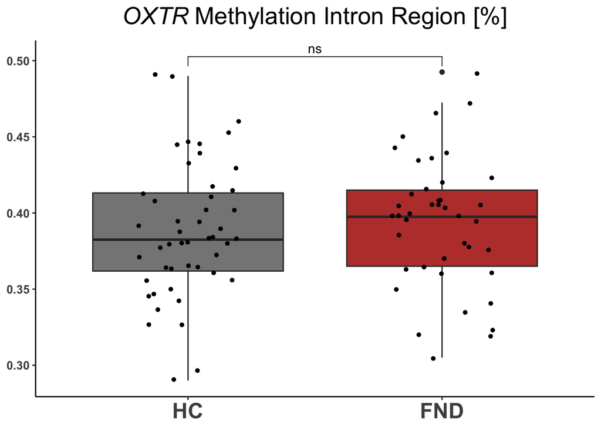

```r
##  Visualization -----------------------------------
# We run a repeated measures Anova on the fitted data. So first a glm, then an Anova on the glm data in order to have covariates included.
df$group <- factor(df$group, levels = c(0, 1), labels = c("HC", "FND"))

# Plot data for OXTR_intron_CpG_average
OXTRboxplot<-ggplot(df, aes(x=group, y=OXTR_intron_CpG_average, fill=group)) +
  geom_boxplot()+
  theme_classic()+
  scale_fill_manual(values = c("#868686FF" ,"#BB4038"))+
  theme(legend.position = "none", axis.title.y = element_blank(),
        axis.title.x = element_blank()) +
  ggtitle(expression(italic("OXTR") ~ "Methylation Intron Region [%]")) +
  theme(plot.title = element_text(hjust = 0.5, size = 20, face = "bold"))+
  theme(axis.title.x=element_blank(),axis.text.y = element_text(size = 10, face = "bold"),
        axis.text.x = element_text(size = 18, face = "bold"), plot.title = element_text(hjust = 0.5))+
  stat_compare_means(label = "p.signif", comparisons = list(c("HC", "FND")), label.x=1)+
  geom_jitter(shape=16, position=position_jitter(0.2))
OXTRboxplot
```

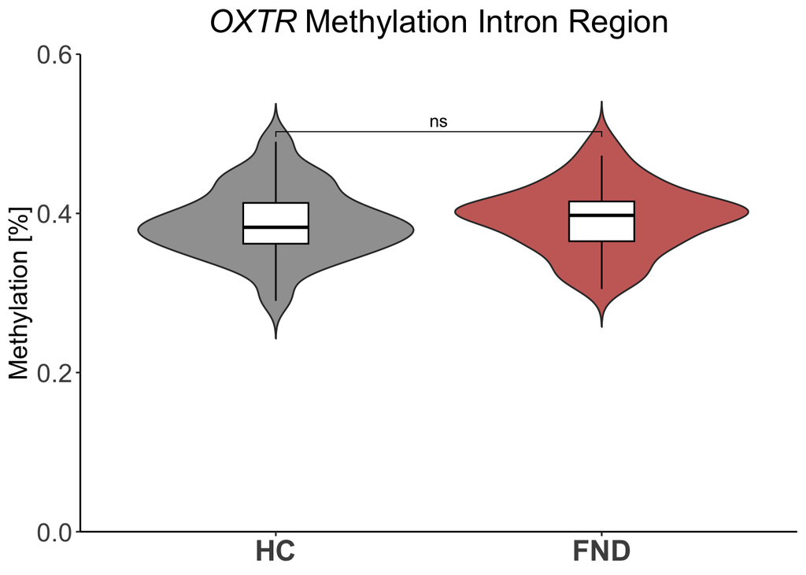

```r
ggsave("3.1_OXTR_intron_boxplot.tiff",
       plot = OXTRboxplot,
       dpi = 600,
       width = 6,
       height = 4,
       units = "in",
       device = "tiff",
       compression = "lzw")

# Visualize with violin plot
OXTRplot <- ggplot(df,aes(x = group, y = OXTR_intron_CpG_average, fill = group)) +
  geom_violin( show.legend = FALSE, alpha = 0.8,   trim = FALSE) +
  geom_boxplot(  width = 0.2, color = "black",fill = "white", show.legend = FALSE, outlier.shape = NA ) +
  scale_fill_manual(values = c("#868686FF", "#BB4038")) +
  stat_compare_means(  label = "p.signif",  comparisons = list(c("HC", "FND")), label.x = 1 ) +
  scale_y_continuous( breaks = seq(0, 0.6, by = 0.2), limits = c(0, 0.6),  expand = c(0, 0) ) +
  labs( title = expression(italic("OXTR") ~ "Methylation Intron Region"), x = NULL,  y = "Methylation [%]" ) +
  theme_classic() +
  theme( plot.title = element_text( hjust = 0.5, size = 20,  face = "bold" ),
     axis.title = element_text(size = 16),
     axis.text.x = element_text(size = 18, face = "bold"),
    axis.text.y = element_text(size = 16),
    legend.position = "none")
OXTRplot
```

```r
ggsave("3.1_OXTR_intron_plot.tiff",
       plot = OXTRplot,
       dpi = 600,
       width = 6,
       height = 4,
       units = "in",
       device = "tiff",
       compression = "lzw")


### separate per site (instead of averaging)
df_introns <- df %>% select(pcode, group, starts_with("OXTR_intron_CpG_"))

df_long <- df_introns %>%
  pivot_longer(
    cols = starts_with("OXTR_intron_CpG_"),
    names_to = "CpG_site",
    values_to = "methylation")
df_long <- df_long %>% mutate( group = factor(group),CpG_site = factor(CpG_site) )

## stat test
stat_test <- df_long %>%
  group_by(CpG_site) %>%
  wilcox_test(methylation ~ group) %>%
  adjust_pvalue(method = "fdr") %>%
  add_significance()
stat_test
```

```
# A tibble: 5 × 10
  CpG_site    .y.   group1 group2    n1    n2 statistic     p p.adj p.adj.signif
  <fct>       <chr> <chr>  <chr>  <int> <int>     <dbl> <dbl> <dbl> <chr>
1 OXTR_intro… meth… HC     FND       48    41      989  0.97  0.97  ns
2 OXTR_intro… meth… HC     FND       48    41      844  0.25  0.625 ns
3 OXTR_intro… meth… HC     FND       48    41     1140  0.2   0.625 ns
4 OXTR_intro… meth… HC     FND       48    41      902. 0.504 0.63  ns
5 OXTR_intro… meth… HC     FND       48    41      882. 0.406 0.63  ns
```

```r
# rename lables
clean_labels <- c(
  "OXTR_intron_CpG_2" = "CpG_2",
  "OXTR_intron_CpG_5" = "CpG_5",
  "OXTR_intron_CpG_6.7" = "CpG_6.7",
  "OXTR_intron_CpG_8" = "CpG_8",
  "OXTR_intron_CpG_average" = "average")

# show pvalue per site
pval_table <- stat_test %>%
  mutate( CpG_site = dplyr::recode(CpG_site, !!!clean_labels),
    p.adj = signif(p.adj, digits = 3)) %>%
  select(CpG_site, p, p.adj) %>%
  arrange(CpG_site)
pval_table # non of the sites has sig difference pvalue
```

```
# A tibble: 5 × 3
  CpG_site     p p.adj
  <fct>    <dbl> <dbl>
1 CpG_2    0.97  0.97
2 CpG_5    0.25  0.625
3 CpG_6.7  0.2   0.625
4 CpG_8    0.504 0.63
5 average  0.406 0.63
```

```r
sink("3.1_intron_CpG_sites.txt")
summary(pval_table)
```

```
    CpG_site       p             p.adj
 CpG_2  :1   Min.   :0.200   Min.   :0.625
 CpG_5  :1   1st Qu.:0.250   1st Qu.:0.625
 CpG_6.7:1   Median :0.406   Median :0.630
 CpG_8  :1   Mean   :0.466   Mean   :0.696
 average:1   3rd Qu.:0.504   3rd Qu.:0.630
             Max.   :0.970   Max.   :0.970
```

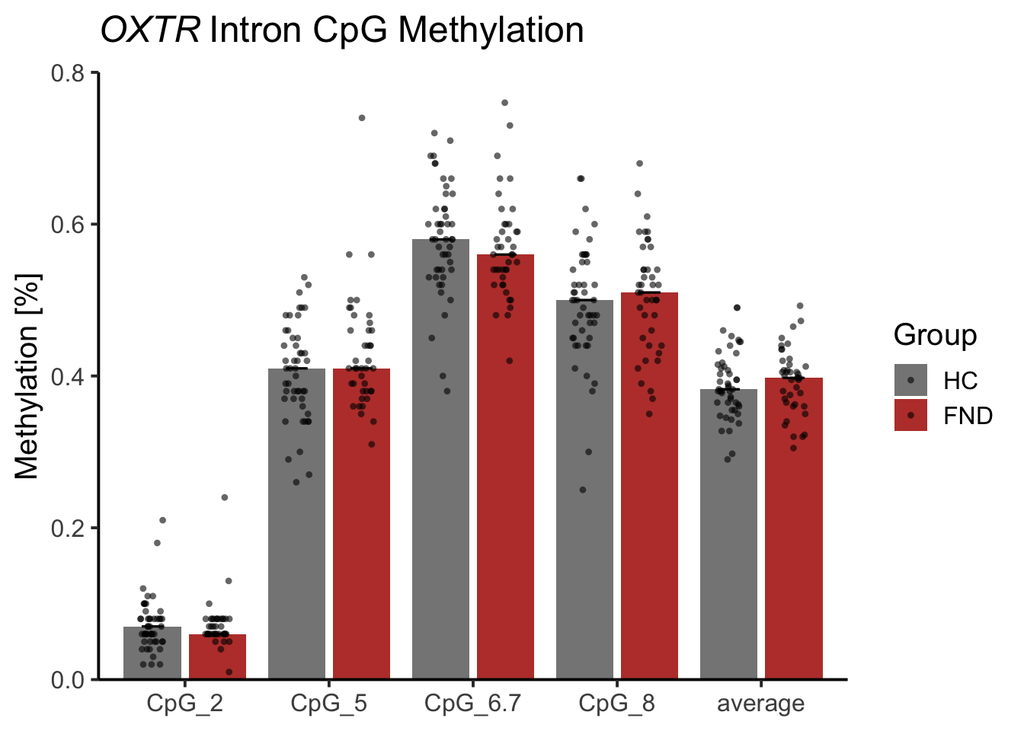

```r
sink()

# Visualize with plot including jitter and CI
# Summary statistics for plotting
alpha <- 0.05
cpg_summary <- df_long %>%
  dplyr::group_by(group, CpG_site) %>%
  dplyr::summarise(
    methylation = median(methylation, na.rm = TRUE),
    Q1 = quantile(methylation, 0.25, na.rm = TRUE),
    Q3 = quantile(methylation, 0.75, na.rm = TRUE),
    .groups = "drop"
  )

dodge <- position_dodge(width = 0.9)
cpg_plot <- ggplot(cpg_summary, aes( x = CpG_site, y = methylation, ymin = Q1, ymax = Q3, fill = group)) +
  geom_bar(position = dodge, stat = "identity", width = 0.8) +
  geom_errorbar(position = dodge, width = 0.3) +
  geom_jitter(data = df_long,
    aes(x = CpG_site, y = methylation, fill = group),
    position = position_jitterdodge(jitter.width = 0.35, dodge.width = 0.9), shape = 16, color = "black",size = 1.2,alpha = 0.6,inherit.aes = FALSE ) +
  scale_fill_manual(values = c("#868686FF", "#BB4038")) +
  scale_x_discrete(labels = clean_labels) +
  scale_y_continuous( breaks = seq(0, 0.8, by = 0.2), limits = c(0, 0.8),  expand = c(0, 0) ) +
  labs( title = expression(italic("OXTR") ~ "Intron CpG Sites"), x = NULL,  y = "Methylation [%]" ,
    fill = "Group") +
  theme_classic() +
  ggtitle(expression(italic("OXTR") ~ "Intron CpG Methylation")) +
  theme_classic(base_size = 15) +
    theme(plot.title = element_text(face = "bold"))
cpg_plot
```

```r
ggsave("3.1_full_Intron_CpGsites.tiff",
       plot = cpg_plot,
       dpi = 600,
       width = 6,
       height = 4,
       units = "in",
       device = "tiff",
       compression = "lzw")

## creating sum scores (apazoglou) and testing the group scores
df <- df %>%
  rowwise() %>%
  mutate(OXTR_intron_CpG_sum = sum(c_across(any_of(c("OXTR_intron_CpG_2", "OXTR_intron_CpG_5", "OXTR_intron_CpG_6.7", "OXTR_intron_CpG_6.7", "OXTR_intron_CpG_8"))),  na.rm = TRUE)) %>%
  ungroup()

stat.test <- df %>%
  wilcox_test(OXTR_intron_CpG_sum ~ group) %>%
  adjust_pvalue(method = "fdr") %>%
  add_significance()
stat.test
```

```
# A tibble: 1 × 9
  .y.               group1 group2    n1    n2 statistic     p p.adj p.adj.signif
  <chr>             <chr>  <chr>  <int> <int>     <dbl> <dbl> <dbl> <chr>
1 OXTR_intron_CpG_… HC     FND       48    41      882. 0.406 0.406 ns
```

```r
## no difference
```

## 3.2) Promoter Region

There is no significant difference between groups (neither as average, nor on each of the specific GcP sites)

```r
## same for promoter region
shapiro.test(df$OXTR_promoter_CpG_average) #  NOT normally distributed with p < 0.05
```

```
    Shapiro-Wilk normality test

data:  df$OXTR_promoter_CpG_average
W = 0.95732, p-value = 0.005191
```

```r
df %>%
  group_by(group) %>%
  get_summary_stats(OXTR_promoter_CpG_average, type = "mean_sd")
```

```
# A tibble: 2 × 5
  group variable                      n  mean    sd
  <fct> <fct>                     <dbl> <dbl> <dbl>
1 HC    OXTR_promoter_CpG_average    48 0.209 0.017
2 FND   OXTR_promoter_CpG_average    41 0.209 0.022
```

```r
stat.test <- df %>%
  wilcox_test(OXTR_promoter_CpG_average ~ group) %>%
  add_significance()
stat.test  # not sig p = 0.439
```

```
# A tibble: 1 × 8
  .y.                       group1 group2    n1    n2 statistic     p p.signif
  <chr>                     <chr>  <chr>  <int> <int>     <dbl> <dbl> <chr>
1 OXTR_promoter_CpG_average HC     FND       48    41     1078. 0.439 ns
```

```r
### sensitivity analyses for medication free group
df_nomed %>%
  group_by(group) %>%
  get_summary_stats(OXTR_promoter_CpG_average, type = "mean_sd")
```

```
# A tibble: 2 × 5
  group variable                      n  mean    sd
  <dbl> <fct>                     <dbl> <dbl> <dbl>
1     0 OXTR_promoter_CpG_average    46 0.209 0.018
2     1 OXTR_promoter_CpG_average    20 0.212 0.021
```

```r
stat.test <- df_nomed %>%
  wilcox_test(OXTR_promoter_CpG_average ~ group) %>%
  add_significance()
stat.test # not sig p = 0.665
```

```
# A tibble: 1 × 8
  .y.                       group1 group2    n1    n2 statistic     p p.signif
  <chr>                     <chr>  <chr>  <int> <int>     <dbl> <dbl> <chr>
1 OXTR_promoter_CpG_average 0      1         46    20      492. 0.665 ns
```

```r
#### FEMALE ONLY
stat.test <- dfOT_female %>%
  wilcox_test(OXTR_promoter_CpG_average ~ group) %>%
  add_significance()
stat.test # not sig p = 0.767
```

```
# A tibble: 1 × 8
  .y.                       group1 group2    n1    n2 statistic     p p.signif
  <chr>                     <chr>  <chr>  <int> <int>     <dbl> <dbl> <chr>
1 OXTR_promoter_CpG_average 0      1         34    29       515 0.767 ns
```

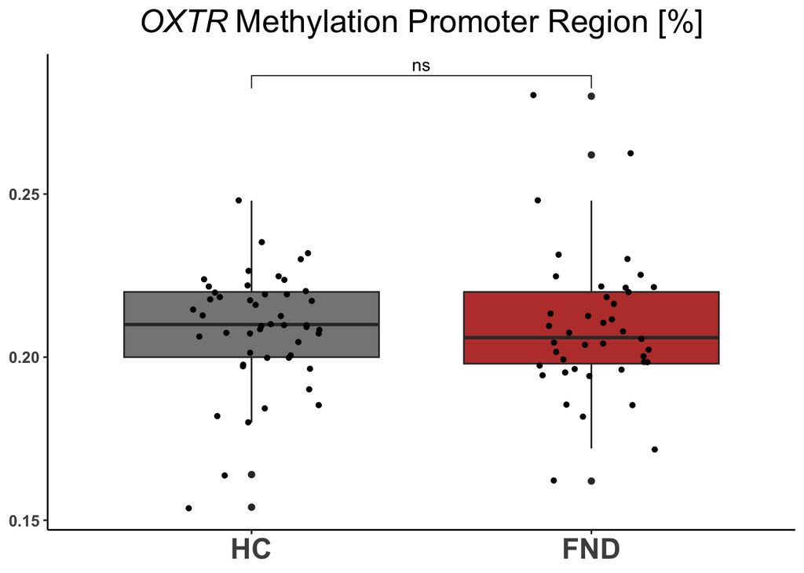

```r
##  Visualization -----------------------------------
# We run a repeated measures Anova on the fitted data.
# Plot data for OXTR_promoter_CpG_average
OXTRboxplot_p<-ggplot(df, aes(x=group, y=OXTR_promoter_CpG_average, fill=group)) +
  geom_boxplot()+
  theme_classic()+
  scale_fill_manual(values = c("#868686FF" ,"#BB4038"))+
  theme(legend.position = "none", axis.title.y = element_blank(),
        axis.title.x = element_blank()) +
    ggtitle(expression(italic("OXTR") ~ "Methylation Promoter Region [%]")) +
  theme(plot.title = element_text(hjust = 0.5, size = 20, face = "bold"))+
  theme(axis.title.x=element_blank(),axis.text.y = element_text(size = 10, face = "bold"),
        axis.text.x = element_text(size = 18, face = "bold"), plot.title = element_text(hjust = 0.5))+
  stat_compare_means(label = "p.signif", comparisons = list(c("HC", "FND")), label.x=1)+
  geom_jitter(shape=16, position=position_jitter(0.2))
OXTRboxplot_p
```

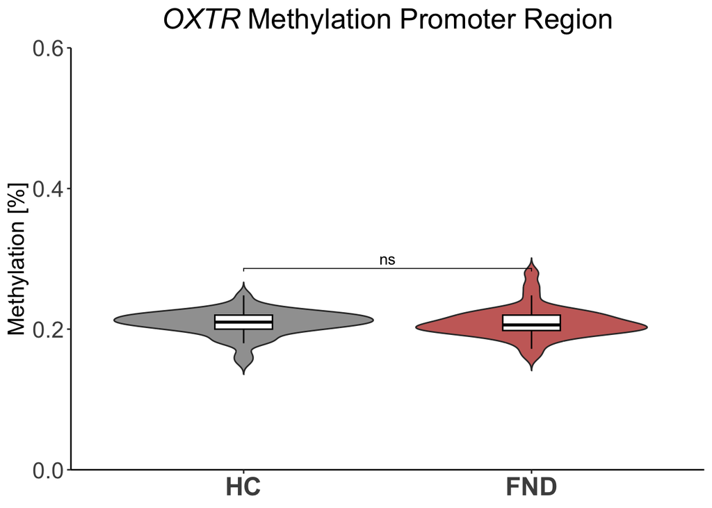

```r
ggsave("3.2_OXTR_pomotor_boxplot.tiff",
       plot = OXTRboxplot_p,
       dpi = 600,
       width = 6,
       height = 4,
       units = "in",
       device = "tiff",
       compression = "lzw")

# Visualize with violin plot
OXTRplot_p <- ggplot(
  df,  aes(x = group, y = OXTR_promoter_CpG_average, fill = group)) +
  geom_violin( show.legend = FALSE,alpha = 0.8, trim = FALSE ) +
  geom_boxplot( width = 0.2,color = "black",fill = "white",show.legend = FALSE,outlier.shape = NA ) +
  scale_fill_manual(values = c("#868686FF", "#BB4038")) +
  stat_compare_means(label = "p.signif",comparisons = list(c("HC", "FND")),label.x = 1) +
  scale_y_continuous( breaks = seq(0, 0.6, by = 0.2), limits = c(0, 0.6),  expand = c(0, 0) ) +
labs( title = expression(italic("OXTR") ~ "Methylation Promoter Region"), x = NULL,  y = "Methylation [%]" ) +  theme_classic() +
  theme( plot.title = element_text( hjust = 0.5,size = 20,face = "bold" ),
        axis.title = element_text(size = 16),
        axis.text.x = element_text(size = 18, face = "bold"),
    axis.text.y = element_text(size = 16),
    legend.position = "none")
OXTRplot_p
```

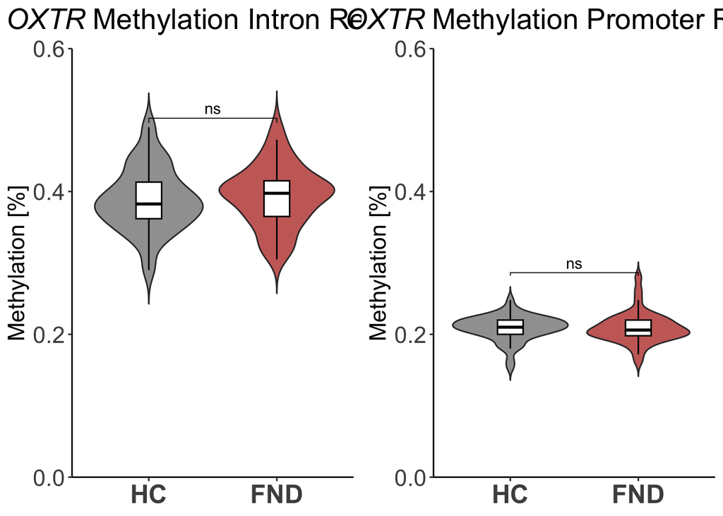

```r
ggsave("3.2_OXTR_pomotor_plot.tiff",
       plot = OXTRplot_p,
       dpi = 600,
       width = 6,
       height = 4,
       units = "in",
       device = "tiff",
       compression = "lzw")
combined <- gridExtra::grid.arrange(OXTRplot, OXTRplot_p, ncol = 2)
```

```r
ggsave("3.2_OXTR_boxplots.tiff",
       plot = combined,
       dpi = 600,
       width = 6,
       height = 4,
       units = "in",
       device = "tiff",
       compression = "lzw")

### separate per site (instead of averaging)
df_promoter <- df %>% select(pcode, group, starts_with("OXTR_promoter_CpG_"))

df_long <- df_promoter %>%
  pivot_longer(
    cols = starts_with("OXTR_promoter_CpG_"),
    names_to = "CpG_site",
    values_to = "methylation")
df_long <- df_long %>% mutate( group = factor(group),CpG_site = factor(CpG_site) )

## stat test
stat_test <- df_long %>%
  group_by(CpG_site) %>%
  wilcox_test(methylation ~ group) %>%
  adjust_pvalue(method = "fdr") %>%
  add_significance()

# rename lables
clean_labels <- c(
  "OXTR_promoter_CpG_2" = "CpG_2",
  "OXTR_promoter_CpG_3" = "CpG_3",
  "OXTR_promoter_CpG_4" = "CpG_4",
  "OXTR_promoter_CpG_5.6" = "CpG_5.6",
  "OXTR_promoter_CpG_8" = "CpG_8",
  "OXTR_promoter_CpG_average" = "average")

# show pvalue per site
pval_table <- stat_test %>%
  mutate( CpG_site = dplyr::recode(CpG_site, !!!clean_labels),
    p.adj = signif(p.adj, digits = 3)) %>%
  select(CpG_site, p, p.adj) %>%
  arrange(CpG_site)
pval_table # non of the sites has sig difference pvalue
```

```
# A tibble: 6 × 3
  CpG_site     p p.adj
  <fct>    <dbl> <dbl>
1 CpG_2    0.686 0.823
2 CpG_3    0.278 0.658
3 CpG_4    0.868 0.868
4 CpG_5.6  0.37  0.658
5 CpG_8    0.333 0.658
6 average  0.439 0.658
```

```r
sink("3.2_promoter_CpG_sites.txt")
summary(pval_table)
```

```
    CpG_site       p              p.adj
 CpG_2  :1   Min.   :0.2780   Min.   :0.6580
 CpG_3  :1   1st Qu.:0.3422   1st Qu.:0.6580
 CpG_4  :1   Median :0.4045   Median :0.6580
 CpG_5.6:1   Mean   :0.4957   Mean   :0.7205
 CpG_8  :1   3rd Qu.:0.6242   3rd Qu.:0.7817
 average:1   Max.   :0.8680   Max.   :0.8680
```

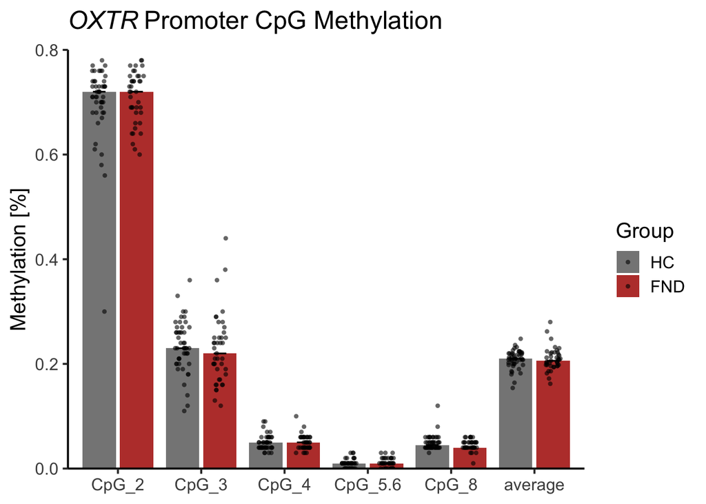

```r
sink()

# Summary statistics for plotting
alpha <- 0.05
cpg_summary <- df_long %>%
  dplyr::group_by(group, CpG_site) %>%
  dplyr::summarise(
    methylation = median(methylation, na.rm = TRUE),
    Q1 = quantile(methylation, 0.25, na.rm = TRUE),
    Q3 = quantile(methylation, 0.75, na.rm = TRUE),
    .groups = "drop"
  )

# Visualize with plot including jitter and CI
dodge <- position_dodge(width = 0.9)
cpg_plot_p <- ggplot(cpg_summary, aes( x = CpG_site, y = methylation,ymin = Q1, ymax = Q3, fill = group)) +
  geom_bar(position = dodge, stat = "identity", width = 0.8) +
  geom_errorbar(position = dodge, width = 0.3) +
  geom_jitter( data = df_long,
    aes(x = CpG_site, y = methylation, fill = group),
    position = position_jitterdodge(jitter.width = 0.35, dodge.width = 0.9), shape = 16, color = "black",size = 1.2,alpha = 0.6,inherit.aes = FALSE ) +
  scale_fill_manual(values = c("#868686FF", "#BB4038")) +
  scale_x_discrete(labels = clean_labels) +
  scale_y_continuous( breaks = seq(0, 0.8, by = 0.2), limits = c(0, 0.8),  expand = c(0, 0) ) +
labs( title = expression(italic("OXTR") ~ "Promoter CpG Sites"), x = NULL,  y = "Methylation [%]" ,
    fill = "Group") +
    ggtitle(expression(italic("OXTR") ~ "Promoter CpG Methylation")) +
  theme_classic(base_size = 15) +
  theme(plot.title = element_text(face = "bold"))
cpg_plot_p
```

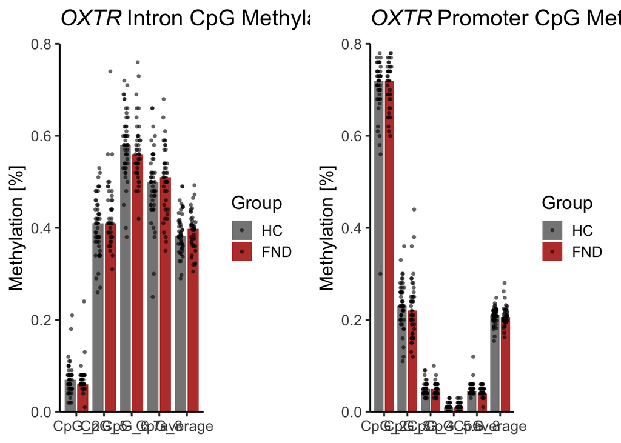

```r
ggsave("3.2_Promoter_CpGsites.tiff",
       plot = cpg_plot_p,
       dpi = 600,
       width = 6,
       height = 4,
       units = "in",
       device = "tiff",
       compression = "lzw")

combined <- gridExtra::grid.arrange(cpg_plot, cpg_plot_p, ncol = 2)
```

```r
ggsave("2_full_boxplots_CpGsites.tiff",
       plot = combined,
       dpi = 600,
       width = 6,
       height = 4,
       units = "in",
       device = "tiff",
       compression = "lzw")

ggsave("3.2_full_boxplots_CpGsites.tiff",
       plot = combined,
       dpi = 600,
       width = 6,
       height = 4,
       units = "in",
       device = "tiff",
       compression = "lzw")
```